# Part II - Ford GoBike Trip Duration per Datetime and User Type

## by Samuel Sarpong

## Investigation Overview

In this investigation, I wanted to take a look at how the duration of trips changes with respect to DateTime and customer type. The main focus was on hours of the day, days of the week and customer type.

## Dataset Overview

The data consists of information regarding approximately 183,000 rides made in a bike-sharing system covering the greater San Francisco Bay area. The data features include duration (secs) and others such as DateTime, customer type, and gender, as well as additional variables such as member's year of birth, start and end station name, start and end station longitude and latitude, start and end station unique id among others. About 8000 data points were removed from the analysis due to inconsistencies or missing information.

## Age Distribution Boxplot

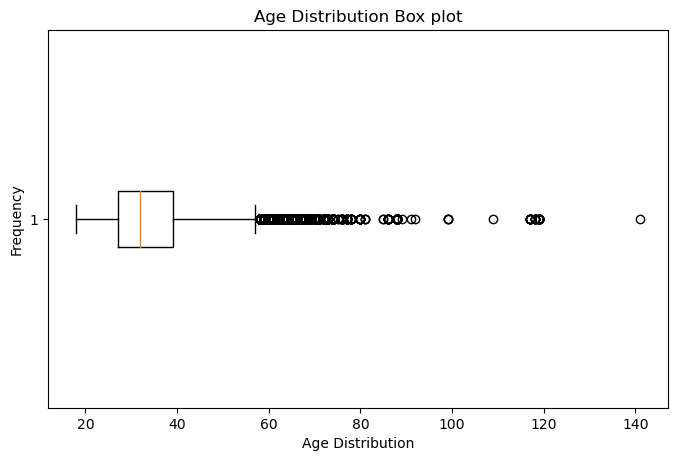

The above plots shows some outliers like an age of over 140yrs and majority of the users were within the 20 to 60 range.

## Distribution of Rides by Hours

> The higher ride frequencies for morning (8th and 9th hours) and evening (17th and 18th hours) can be linked to rush hours where people leave for work and come back later in the evening.

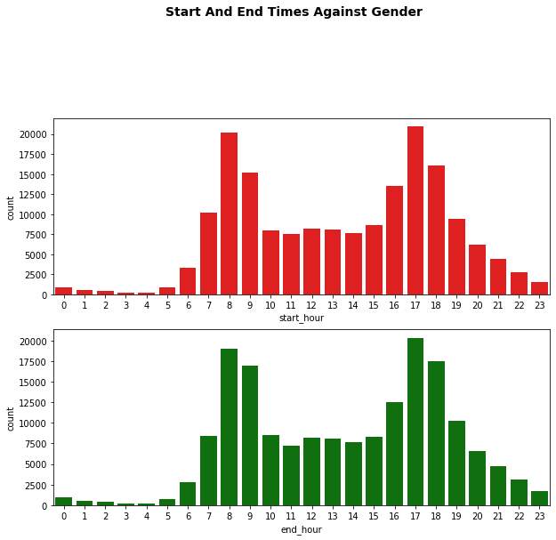

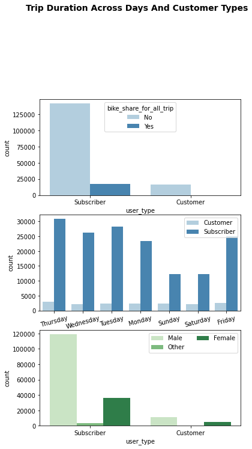

## Relationship between Days, Hours and Gender

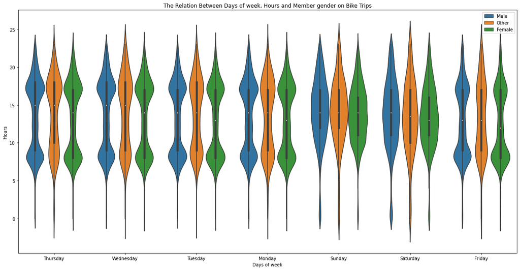

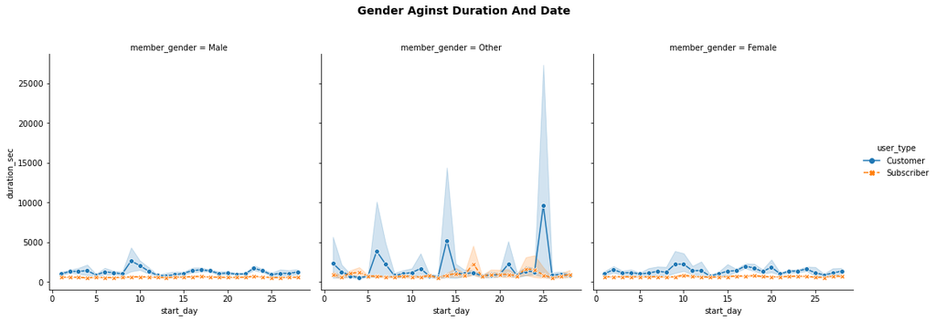

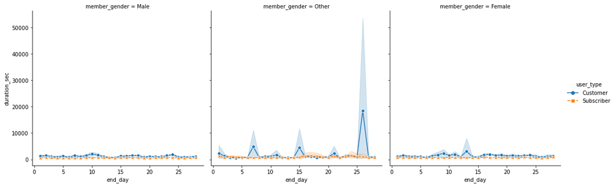

- For male customers most riding duration when the customer starts the ride in the second week of the month
- For male customers most rides duration ends with the 10th of the month
- For Female customers the rides with the most duration are in the second week of the month too
- For Female customers rides ends between the 10th and the 15th are with the most duration
- Subscribers both male and female don't give that much of details